# Final Exam Dataset #4: Personality

# The 16 Personality Factor dataset

Attached is a dataset about Personality, obtained using online questionnaire data. It covers 16 different aspects ("factors") of personality.

The goal is to investigate the basic question: *is there a good model for personality?* You get to determine whether data science can provide an answer.

# An ongoing debate about models of "Personality"

Two opposing theories about how to model Personality have been proposed:

1. Personality should be definable by classes that are organized into a taxonomy,
2. Personality should be organized as a *k*-dimensional real-valued "vector space" in which each personality corresponds to an *k*-dimensional point.

The tradition in psychology (and biology generally) has been to emphasize taxonomic models. Recently, however, dimensional models have been gaining credibility as an alternative.

There are strong arguments on both side of this debate. The implications of a good resolution would be massive, since medical decisions involving "psychiatry" depend on how people are characterized. Today many diagnoses are based entirely on decision trees, and a taxonomic characterizations. Doctors are supposed to follow the decision trees rigorously, although many of the descriptions involved are vague.

There is a long history here, and there are many reasons why the debate is difficult to resolve. We can explore whether the topics we have covered in this class are useful in understanding the basic issues.

# WHAT TO DO WITH THE 16 PERSONALITY FACTOR DATASET

1. **Study "taxonomic models" of Personality:**
   - Study the cluster structure of personalities, using a clustering method like *k*-means.
   - Develop a "taxonomy" of personalities, using a decision tree classifier.
   - Develop a "taxonomy" of personalities, using a discriminant analysis method like LDA, QDA, or SVM.
   - Compare the accuracy of these classifier methods.
2. **Study "dimensional models" of Personality:**
   - Study the dimensional structure of personalities, using dimensionality reduction methods.
   - Develop a "dimensional model" of personalities (a vector-space model), using a method like PCA or ICA.
   - Develop a "dimensional model" of personalities, using matrix decomposition.
   - Compare the accuracy of these dimensional methods.
3. **Decide whether "taxonomic models" or "dimensional models" are better for Personality.**

All of these analyses can be done with scikit-learn; please use it for your analysis.

More details are below.

# DO YOUR OWN WORK.

All notebooks will be analyzed for similarity.

## Schema of the Dataset

The dataset has the following columns:

| **A1-A10** | Warmth questions |
| --- | --- |
| **B1-B13** | Intellect questions |
| **C1-C10** | Stability questions |
| **D1-D10** | Assertiveness questions |
| **E1-E10** | Gregariousness questions |
| **F1-F10** | Dutifulness questions |
| **G1-G10** | Friendlinesss questions |
| **H1-H10** | Sensitivity questions |
| **I1-I10** | Distrust questions |
| **J1-J10** | Imagination questions |
| **K1-K10** | Reserve questions |
| **L1-L10** | Anxiety questions |
| **M1-M10** | Complexity questions |
| **N1-N10** | Introversion questions |
| **O1-O10** | Orderliness questions |
| **P1-P10** | Emotionality questions |
| **age** | Age, in years, of the subject completing the questionnaire |
| **gender** | 1 = Male, 2 = Female |
| **accuracy** | Value provided by the answerer (after completing the questionnaire) about the accuracy of the answers; only values of 80 or more were retained. |
| **country** | two-letter code of originating country (see below) |
| **source** | Came from: 1=survey, 2=google, 3=facebook, 4=url containing ".edu", 5=wikipedia, 6=other/unknown source. |
| **elapsed** | Seconds of elapsed time for completing the questionnaire |
| **Warmth** | Warmth = A1 + A2 + A3 + A4 + A5 + A6 + A7 - A8 - A9 - A10 |
| **Intellect** | Intellect = B1 + B2 + B3 + B4 + B5 + B6 + B7 + B8 - B9 - B10 - B11 - B12 - B13 |
| **Stability** | Stability = C1 + C2 + C3 + C4 + C5 - C6 - C7 - C8 - C9 - C10 |
| **Assertiveness** | Assertiveness = D1 + D2 + D3 + D4 + D5 + D6 - D7 - D8 - D9 - D10 |
| **Gregariousness** | Gregariousness = E1 + E2 + E3 + E4 + E5 + E6 - E7 - E8 - E9 - E10 |
| **Dutifulness** | Dutifulness = F1 + F2 + F3 + F4 + F5 - F6 - F7 - F8 - F9 - F10 |
| **Friendliness** | Friendliness = G1 + G2 + G3 + G4 + G5 - G6 - G7 - G8 - G9 - G10 |
| **Sensitivity** | Sensitivity = H1 + H2 + H3 + H4 + H5 + H6 - H7 - H8 - H9 - H10 |
| **Distrust** | Distrust = I1 + I2 + I3 + I4 + I5 - I6 - I7 - I8 - I9 - I10 |
| **Imagination** | Imagination = J1 + J2 + J3 + J4 + J5 + J6 + J7 - J8 - J9 - J10 |
| **Reserve** | Reserve = K1 + K2 + K3 + K4 + K5 - K6 - K7 - K8 - K9 - K10 |
| **Anxiety** | Anxiety = L1 + L2 + L3 + L4 + L5 + L6 + L7 - L8 - L9 - L10 |
| **Complexity** | Complexity = M1 + M2 + M3 + M4 + M5 - M6 - M7 - M8 - M9 - M10 |
| **Introversion** | Introversion = N1 + N2 + N3 + N4 + N5 + N6 + N7 - N8 - N9 - N10 |
| **Orderliness** | Orderliness = O1 + O2 + O3 + O4 + O5 - O6 - O7 - O8 - O9 - O10 |
| **Emotionality** | Emotionality = P1 + P2 + P3 + P4 + P5 + P6 + P7 - P8 - P9 - P10 |

## Questions in the Questionnaire

| **WARMTH** | (Warmth) |
| --- | --- |
| **+A1** | I know how to comfort others |
| **+A2** | I enjoy bringing people together |
| **+A3** | I feel others' emotions |
| **+A4** | I take an interest in other people's lives |
| **+A5** | I cheer people up |
| **+A6** | I make people feel at ease |
| **+A7** | I take time out for others |
| **-A8** | I don't like to get involved in other people's problems |
| **-A9** | I am not really interested in others |
| **-A10** | I try not to think about the needy |
| **INTELLECT** | (Reasoning) |
| **+B1** | I make insightful remarks |
| **+B2** | I know the answers to many questions |
| **+B3** | I tend to analyze things |
| **+B4** | I use my brain |
| **+B5** | I learn quickly |
| **+B6** | I counter others' arguments |
| **+B7** | I reflect on things before acting |
| **+B8** | I weigh the pros against the cons |
| **-B9** | I consider myself an average person |
| **-B10** | I get confused easily |
| **-B11** | I know that I am not a special person |
| **-B12** | I have a poor vocabulary |
| **-B13** | I skip difficult words while reading |
| **EMOTIONAL STABILITY** | (Emotional Stability) |
| **+C1** | I seldom feel blue |
| **+C2** | I feel comfortable with myself |
| **+C3** | I readily overcome setbacks |
| **+C4** | I am relaxed most of the time |
| **+C5** | I am not easily frustrated |

[output cut: 148 more lines]

Please note that the dataset has missing values in one column.

# A First Look at the Dataset

```python
import pandas as pd
import numpy as np

pd.options.display.max_columns = 50
pd.options.display.width = 1000
```

# Clean the Raw Data

The dataset has lots of bad data in it: apparently it was gathered by just leaving the questionnaire open for submissions on the web.

Although there are 49K lines in the dataset at least 25% of these look bad.

```python
raw = open('PersonalityRawData.csv', 'r')
PersonalityRawData = raw.readlines()
raw.close()

len(PersonalityRawData)
```

```
49160
```

```python
import re
bad_data_patterns = [ r',,',   # missing values
                     r'0,0,0,0,0,0,0,0,0,0,0,0,0,0,0,0,0,',
                     r'1,1,1,1,1,1,1,1,1,1,1,1,1,1,1,1,1,',
                     r'2,2,2,2,2,2,2,2,2,2,2,2,2,2,2,2,2,',  # too many instances of a score
                     r'3,3,3,3,3,3,3,3,3,3,3,3,3,3,3,3,3,',
                     r'4,4,4,4,4,4,4,4,4,4,4,4,4,4,4,4,4,',
                     r'5,5,5,5,5,5,5,5,5,5,5,5,5,5,5,5,5,5,5,5,5',
                     r'^[^1]*[A-Z]',
                     r'^[^2]*[A-Z]',
                     r'^[^3]*[A-Z]',  # no instances of a score
                     r'^[^4]*[A-Z]',
                     r'^[^5]*[A-Z]',
                     r',A1,',
                     r',A2,',   # bad country codes
                     r',O1,', ]

compiled_bad_data_patterns = [re.compile(pattern) for pattern in bad_data_pattern]

def not_bad(line):
    for pattern in compiled_bad_data_patterns:
        if pattern.search(line):
            return False
    return True
```

```python
clean_lines = [PersonalityRawData[0]]   #  Header line in the .csv file
for line in PersonalityRawData[1:]:
    if not_bad(line):
        cleaned_line = line.replace(',NA,',',NM,')  # replace the country code of Namibia
        clean_lines += [cleaned_line]
```

```python
clean = open('PersonalityCleanedData.csv', 'w')
clean.write( ''.join(clean_lines) )
clean.close()

Personality = pd.DataFrame.from_csv('PersonalityCleanedData.csv').reset_index()

Personality.shape
```

```
(46845, 169)
```

```python
Personality = Personality[ Personality.age <= 90 ]       # omit very high age values
Personality = Personality[ Personality.gender >= 1 ]
Personality = Personality[ Personality.gender <= 2 ]     # omit gender codes 0 and 3 (see below)
Personality = Personality[ Personality.elapsed < 5000 ]  # omit questionnaire results taking long than 5000 seconds
Personality = Personality[ Personality.accuracy > 80 ]   # omit accuracy values below 80
Personality = Personality[ Personality.accuracy <= 100 ] # omit accuracy values above 100

Personality.shape
```

```
(34807, 169)
```

```python
print( Personality[Personality.age > 80].shape )
```

```
(6, 169)
```

# A first look at the Cleaned Data

```python
Personality.head()
```

|  | A1 | A2 | A3 | A4 | A5 | A6 | A7 | A8 | A9 | A10 | B1 | B2 | B3 | B4 | B5 | B6 | B7 | B8 | B9 | B10 | B11 | B12 | B13 | C1 | C2 | ... | O2 | O3 | O4 | … |
| --- | --- | --- | --- | --- | --- | --- | --- | --- | --- | --- | --- | --- | --- | --- | --- | --- | --- | --- | --- | --- | --- | --- | --- | --- | --- | --- | --- | --- | --- | --- |
| 0 | 1 | 4 | 2 | 3 | 3 | 2 | 3 | 4 | 4 | 3 | 4 | 4 | 5 | 4 | 5 | 4 | 5 | 4 | 1 | 2 | 1 | 1 | 1 | 4 | 5 | ... | 2 | 3 | 4 | … |
| 1 | 4 | 3 | 4 | 3 | 4 | 4 | 4 | 4 | 2 | 2 | 4 | 4 | 4 | 4 | 5 | 4 | 3 | 2 | 3 | 2 | 4 | 1 | 1 | 1 | 2 | ... | 2 | 4 | 2 | … |
| 3 | 4 | 5 | 4 | 4 | 4 | 3 | 3 | 2 | 2 | 2 | 4 | 2 | 4 | 5 | 4 | 5 | 4 | 4 | 3 | 3 | 3 | 2 | 4 | 3 | 2 | ... | 2 | 2 | 2 | … |
| 4 | 4 | 0 | 4 | 4 | 4 | 3 | 5 | 1 | 2 | 4 | 2 | 4 | 4 | 5 | 5 | 4 | 4 | 5 | 4 | 1 | 5 | 1 | 2 | 2 | 4 | ... | 3 | 5 | 3 | … |
| 7 | 4 | 5 | 4 | 4 | 4 | 4 | 5 | 2 | 2 | 2 | 3 | 3 | 4 | 5 | 4 | 4 | 4 | 5 | 4 | 2 | 3 | 1 | 1 | 3 | 4 | ... | 3 | 4 | 4 | … |

5 rows × 169 columns

```python
Personality.shape
```

```
(34807, 169)
```

```python
ages = Personality[['age']].values

youngest = np.min(ages)
oldest = np.max(ages)

print((youngest, oldest))
```

```
(13, 90)
```

```python
import matplotlib.pyplot as plt
%matplotlib inline
plt.rcParams['figure.figsize'] = (10.0, 8.0)
```

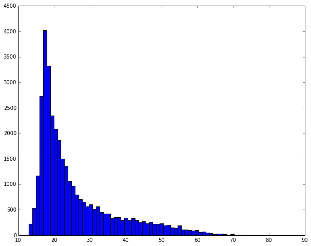

```python
plt.hist( ages, bins=len(range(youngest,oldest+1)) )
plt.show()
```

```python
Personality.columns
```

```
Index([u'A1', u'A2', u'A3', u'A4', u'A5', u'A6', u'A7', u'A8', u'A9', u'A10', u'B1', u'B2', u'B3', u'B4', u'B5', u'B6', u'B7', u'B8', u'B9', u'B10', u'B11', u'B12', u'B13', u'C1', u'C2', u'C3', u'C4', u'C5', u'C6', u'C7', u'C8', u'C9', u'C10', u'D1', u'D2', u'D3', u'D4', u'D5', u'D6', u'D7', u'D8', …
```

```python
ages[ (ages>70), ]
```

```
array([88, 73, 72, 79, 73, 81, 72, 80, 87, 82, 79, 72, 90, 85, 73, 78, 71,
       76, 76, 74, 72, 72, 71, 72, 71, 71, 72])
```

# Add the 16 Personality Factor scores

```python
P = Personality

Warmth = P.A1 + P.A2 + P.A3 + P.A4 + P.A5 + P.A6 + P.A7 - P.A8 - P.A9 - P.A10
Intellect = P.B1 + P.B2 + P.B3 + P.B4 + P.B5 + P.B6 + P.B7 + P.B8 - P.B9 - P.B10 - P.B11 - P.B12 - P.B13
Stability = P.C1 + P.C2 + P.C3 + P.C4 + P.C5 - P.C6 - P.C7 - P.C8 - P.C9 - P.C10
Assertiveness = P.D1 + P.D2 + P.D3 + P.D4 + P.D5 + P.D6 - P.D7 - P.D8 - P.D9 - P.D10
Gregariousness = P.E1 + P.E2 + P.E3 + P.E4 + P.E5 + P.E6 - P.E7 - P.E8 - P.E9 - P.E10
Dutifulness = P.F1 + P.F2 + P.F3 + P.F4 + P.F5 - P.F6 - P.F7 - P.F8 - P.F9 - P.F10
Friendliness = P.G1 + P.G2 + P.G3 + P.G4 + P.G5 - P.G6 - P.G7 - P.G8 - P.G9 - P.G10
Sensitivity = P.H1 + P.H2 + P.H3 + P.H4 + P.H5 + P.H6 - P.H7 - P.H8 - P.H9 - P.H10
Distrust = P.I1 + P.I2 + P.I3 + P.I4 + P.I5 - P.I6 - P.I7 - P.I8 - P.I9 - P.I10
Imagination = P.J1 + P.J2 + P.J3 + P.J4 + P.J5 + P.J6 + P.J7 - P.J8 - P.J9 - P.J10
Reserve = P.K1 + P.K2 + P.K3 + P.K4 + P.K5 - P.K6 - P.K7 - P.K8 - P.K9 - P.K10
Anxiety = P.L1 + P.L2 + P.L3 + P.L4 + P.L5 + P.L6 + P.L7 - P.L8 - P.L9 - P.L10
Complexity = P.M1 + P.M2 + P.M3 + P.M4 + P.M5 - P.M6 - P.M7 - P.M8 - P.M9 - P.M10
Introversion = P.N1 + P.N2 + P.N3 + P.N4 + P.N5 + P.N6 + P.N7 - P.N8 - P.N9 - P.N10
Orderliness = P.O1 + P.O2 + P.O3 + P.O4 + P.O5 - P.O6 - P.O7 - P.O8 - P.O9 - P.O10
Emotionality = P.P1 + P.P2 + P.P3 + P.P4 + P.P5 + P.P6 + P.P7 - P.P8 - P.P9 - P.P10

Personality['Warmth'] = Warmth
Personality['Intellect'] = Intellect
Personality['Stability'] = Stability
Personality['Assertiveness'] = Assertiveness
Personality['Gregariousness'] = Gregariousness
Personality['Dutifulness'] = Dutifulness
Personality['Friendliness'] = Friendliness
Personality['Sensitivity'] = Sensitivity
Personality['Distrust'] = Distrust
Personality['Imagination'] = Imagination
Personality['Reserve'] = Reserve
Personality['Anxiety'] = Anxiety
Personality['Complexity'] = Complexity
Personality['Introversion'] = Introversion
Personality['Orderliness'] = Orderliness
Personality['Emotionality'] = Emotionality
```

```python
Personality.shape
```

```
(34807, 185)
```

```python
np.count_nonzero( Personality.Warmth )
```

```
34721
```

```python
Personality.columns[-20:]  # names of the last 20 columns
```

```
Index([u'accuracy', u'country', u'source', u'elapsed', u'Warmth', u'Intellect', u'Stability', u'Assertiveness', u'Gregariousness', u'Dutifulness', u'Friendliness', u'Sensitivity', u'Distrust', u'Imagination', u'Reserve', u'Anxiety', u'Complexity', u'Introversion', u'Orderliness', u'Emotionality'], d…
```

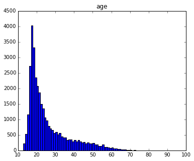

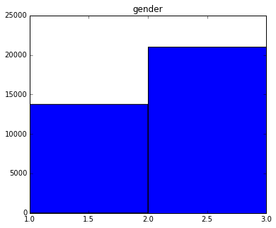

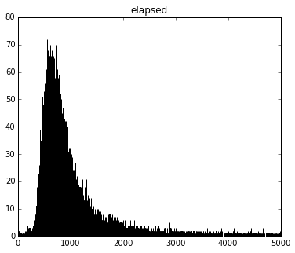

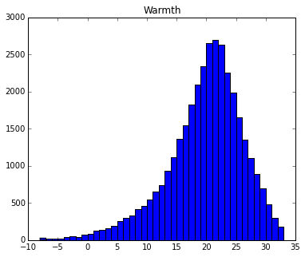

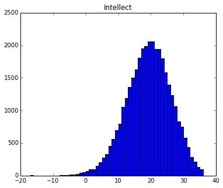

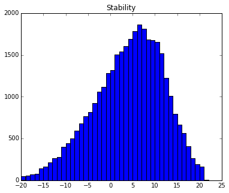

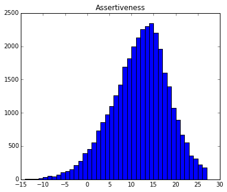

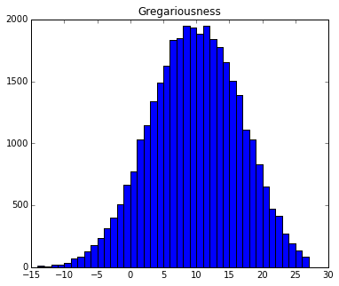

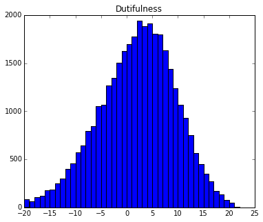

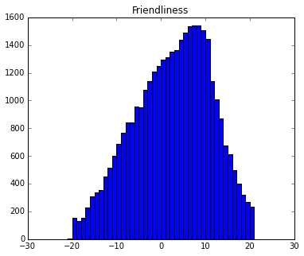

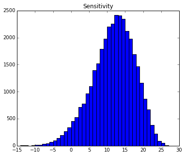

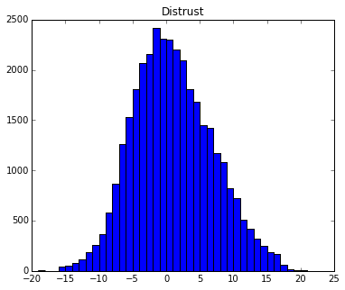

[7 more figures not shown]

```python
plt.rcParams['figure.figsize'] = (6.0, 5.0)

for ColName in ['age', 'gender', 'elapsed',
    'Warmth', 'Intellect', 'Stability', 'Assertiveness', 'Gregariousness',
    'Dutifulness', 'Friendliness', 'Sensitivity', 'Distrust', 'Imagination',
    'Reserve', 'Anxiety', 'Complexity', 'Introversion', 'Orderliness', 'Emotionality']:  ### Personality.columns:
    ColValues = Personality[[ColName]].values
    plt.hist( ColValues, bins=range(min(ColValues), max(ColValues)+2) )
    plt.title( ColName )
    plt.show()
```

```python
# This isn't used now, but is included anyway

CountryCode = {'A1': "Anonymous Proxy", 'A2': "Satellite Provider", 'O1': "Other Country", 'AD': "Andorra", 'AE': "United Arab Emirates",
'AF': "Afghanistan", 'AG': "Antigua and Barbuda", 'AI': "Anguilla", 'AL': "Albania", 'AM': "Armenia", 'AO': "Angola",
'AP': "Asia/Pacific Region", 'AQ': "Antarctica", 'AR': "Argentina", 'AS': "American Samoa", 'AT': "Austria", 'AU': "Australia",
'AW': "Aruba", 'AX': "Aland Islands", 'AZ': "Azerbaijan", 'BA': "Bosnia and Herzegovina", 'BB': "Barbados", 'BD': "Bangladesh",
'BE': "Belgium", 'BF': "Burkina Faso", 'BG': "Bulgaria", 'BH': "Bahrain", 'BI': "Burundi", 'BJ': "Benin", 'BL': "Saint Bartelemey",
'BM': "Bermuda", 'BN': "Brunei Darussalam", 'BO': "Bolivia", 'BQ': "Bonaire, Saint Eustatius and Saba", 'BR': "Brazil", 'BS': "Bahamas",
'BT': "Bhutan", 'BV': "Bouvet Island", 'BW': "Botswana", 'BY': "Belarus", 'BZ': "Belize", 'CA': "Canada", 'CC': "Cocos (Keeling) Islands",
'CD': "Congo, The Democratic Republic of the", 'CF': "Central African Republic", 'CG': "Congo", 'CH': "Switzerland", 'CI': "Cote d'Ivoire",
'CK': "Cook Islands", 'CL': "Chile", 'CM': "Cameroon", 'CN': "China", 'CO': "Colombia", 'CR': "Costa Rica", 'CU': "Cuba",
'CV': "Cape Verde", 'CW': "Curacao", 'CX': "Christmas Island", 'CY': "Cyprus", 'CZ': "Czech Republic", 'DE': "Germany", 'DJ': "Djibouti",
'DK': "Denmark", 'DM': "Dominica", 'DO': "Dominican Republic", 'DZ': "Algeria", 'EC': "Ecuador", 'EE': "Estonia", 'EG': "Egypt",
'EH': "Western Sahara", 'ER': "Eritrea", 'ES': "Spain", 'ET': "Ethiopia", 'EU': "Europe", 'FI': "Finland", 'FJ': "Fiji",
'FK': "Falkland Islands (Malvinas)", 'FM': "Micronesia, Federated States of", 'FO': "Faroe Islands", 'FR': "France", 'GA': "Gabon",
'GB': "United Kingdom", 'GD': "Grenada", 'GE': "Georgia", 'GF': "French Guiana", 'GG': "Guernsey", 'GH': "Ghana", 'GI': "Gibraltar",
'GL': "Greenland", 'GM': "Gambia", 'GN': "Guinea", 'GP': "Guadeloupe", 'GQ': "Equatorial Guinea", 'GR': "Greece",
'GS': "South Georgia and the South Sandwich Islands", 'GT': "Guatemala", 'GU': "Guam", 'GW': "Guinea-Bissau", 'GY': "Guyana",
'HK': "Hong Kong", 'HM': "Heard Island and McDonald Islands", 'HN': "Honduras", 'HR': "Croatia", 'HT': "Haiti", 'HU': "Hungary",
'ID': "Indonesia", 'IE': "Ireland", 'IL': "Israel", 'IM': "Isle of Man", 'IN': "India", 'IO': "British Indian Ocean Territory",
'IQ': "Iraq", 'IR': "Iran, Islamic Republic of", 'IS': "Iceland", 'IT': "Italy", 'JE': "Jersey", 'JM': "Jamaica", 'JO': "Jordan",
'JP': "Japan", 'KE': "Kenya", 'KG': "Kyrgyzstan", 'KH': "Cambodia", 'KI': "Kiribati", 'KM': "Comoros", 'KN': "Saint Kitts and Nevis",
'KP': "Korea, Democratic People's Republic of", 'KR': "Korea, Republic of", 'KW': "Kuwait", 'KY': "Cayman Islands", 'KZ': "Kazakhstan",
'LA': "Lao People's Democratic Republic", 'LB': "Lebanon", 'LC': "Saint Lucia", 'LI': "Liechtenstein", 'LK': "Sri Lanka", 'LR': "Liberia",
'LS': "Lesotho", 'LT': "Lithuania", 'LU': "Luxembourg", 'LV': "Latvia", 'LY': "Libyan Arab Jamahiriya", 'MA': "Morocco", 'MC': "Monaco",
'MD': "Moldova, Republic of", 'ME': "Montenegro", 'MF': "Saint Martin", 'MG': "Madagascar", 'MH': "Marshall Islands", 'MK': "Macedonia",
'ML': "Mali", 'MM': "Myanmar", 'MN': "Mongolia", 'MO': "Macao", 'MP': "Northern Mariana Islands", 'MQ': "Martinique", 'MR': "Mauritania",
'MS': "Montserrat", 'MT': "Malta", 'MU': "Mauritius", 'MV': "Maldives", 'MW': "Malawi", 'MX': "Mexico", 'MY': "Malaysia",
'MZ': "Mozambique", 'NA': "Namibia", 'NC': "New Caledonia", 'NE': "Niger", 'NF': "Norfolk Island", 'NG': "Nigeria", 'NI': "Nicaragua",
'NL': "Netherlands", 'NO': "Norway", 'NP': "Nepal", 'NR': "Nauru", 'NU': "Niue", 'NZ': "New Zealand", 'OM': "Oman", 'PA': "Panama",
'PE': "Peru", 'PF': "French Polynesia", 'PG': "Papua New Guinea", 'PH': "Philippines", 'PK': "Pakistan", 'PL': "Poland",
'PM': "Saint Pierre and Miquelon", 'PN': "Pitcairn", 'PR': "Puerto Rico", 'PS': "Palestinian Territory", 'PT': "Portugal", 'PW': "Palau",
'PY': "Paraguay", 'QA': "Qatar", 'RE': "Reunion", 'RO': "Romania", 'RS': "Serbia", 'RU': "Russian Federation", 'RW': "Rwanda",
'SA': "Saudi Arabia", 'SB': "Solomon Islands", 'SC': "Seychelles", 'SD': "Sudan", 'SE': "Sweden", 'SG': "Singapore", 'SH': "Saint Helena",
'SI': "Slovenia", 'SJ': "Svalbard and Jan Mayen", 'SK': "Slovakia", 'SL': "Sierra Leone", 'SM': "San Marino", 'SN': "Senegal",
'SO': "Somalia", 'SR': "Suriname", 'SS': "South Sudan", 'ST': "Sao Tome and Principe", 'SV': "El Salvador", 'SX': "Sint Maarten",
'SY': "Syrian Arab Republic", 'SZ': "Swaziland", 'TC': "Turks and Caicos Islands", 'TD': "Chad", 'TF': "French Southern Territories",
'TG': "Togo", 'TH': "Thailand", 'TJ': "Tajikistan", 'TK': "Tokelau", 'TL': "Timor-Leste", 'TM': "Turkmenistan", 'TN': "Tunisia",
'TO': "Tonga", 'TR': "Turkey", 'TT': "Trinidad and Tobago", 'TV': "Tuvalu", 'TW': "Taiwan", 'TZ': "Tanzania, United Republic of",
'UA': "Ukraine", 'UG': "Uganda", 'UM': "United States Minor Outlying Islands", 'US': "United States", 'UY': "Uruguay", 'UZ': "Uzbekistan",
'VA': "Holy See (Vatican City State)", 'VC': "Saint Vincent and the Grenadines", 'VE': "Venezuela", 'VG': "Virgin Islands, British",
'VI': "Virgin Islands, U.S.", 'VN': "Vietnam", 'VU': "Vanuatu", 'WF': "Wallis and Futuna", 'WS': "Samoa", 'YE': "Yemen", 'YT': "Mayotte",
'ZA': "South Africa", 'ZM': "Zambia", 'ZW': "Zimbabwe"}
```